## Homework 5

*Enter your name and EID here*

**This homework is due on Mar. 1, 2016 at 11:59pm. Please submit as a PDF file on Canvas.**

*For this homework you will use the `wine` data set. The `wine` data set contains concentrations of 13 different chemical compounds (`chem1`-`chem13`) in 178 samples of wines grown in Italy. Each row is a different sample of wine, and the data set contains three different cultivars (`cultivar`) of wine.*

```r
wine <- read.csv("http://wilkelab.org/classes/SDS348/data_sets/wine.csv", colClasses = c("cultivar" = "factor"))
head(wine)
```

```
##   cultivar chem1 chem2 chem3 chem4 chem5 chem6 chem7 chem8 chem9 chem10
## 1        1 14.23  1.71  2.43  15.6   127  2.80  3.06  0.28  2.29   5.64
## 2        1 13.20  1.78  2.14  11.2   100  2.65  2.76  0.26  1.28   4.38
## 3        1 13.16  2.36  2.67  18.6   101  2.80  3.24  0.30  2.81   5.68
## 4        1 14.37  1.95  2.50  16.8   113  3.85  3.49  0.24  2.18   7.80
## 5        1 13.24  2.59  2.87  21.0   118  2.80  2.69  0.39  1.82   4.32
## 6        1 14.20  1.76  2.45  15.2   112  3.27  3.39  0.34  1.97   6.75
##   chem11 chem12 chem13
## 1   1.04   3.92   1065
## 2   1.05   3.40   1050
## 3   1.03   3.17   1185
## 4   0.86   3.45   1480
## 5   1.04   2.93    735
## 6   1.05   2.85   1450
```

**Question 1 (3 pts):** *Perform a principal components analysis (PCA). Since the chemical concentrations may span several orders of magnitude across different compounds, be sure to **scale** the data (using `scale`) before doing PCA. Create a scatterplot of PC1 vs. PC2 and color each point by cultivar. What do you observe? Visually, and without doing any calculations, do the cultivars cluster together in principal-component space?*

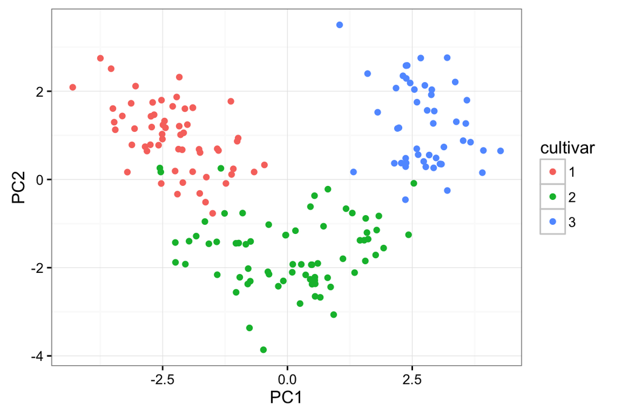

```r
wine %>% select(-cultivar) %>% scale() %>% prcomp() -> pca
pca_data <- data.frame(pca$x, cultivar=wine$cultivar)
ggplot(pca_data, aes(x=PC1, y=PC2, color=cultivar)) + geom_point()
```

*The wines seem to cluster into three distinct groups based on the cultivar.*

**Question 2 (4 pts):** *Now take your matrix of **principal components coordinates** (not the raw chemical concentration data!) from Question 1 above and cluster the wines into 3 groups (`centers=3`) using k-means clustering with 10 random starts (`nstart=10`). Create a scatterplot of PC1 vs. PC2. This time, color each point by **cluster** and set the plotting symbol by **cultivar**. What do you observe?*

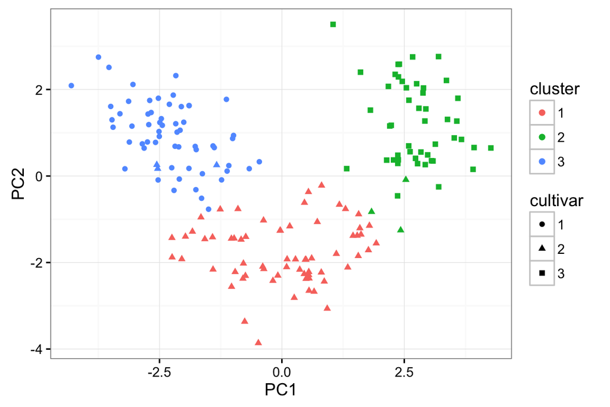

```r
pca$x %>% kmeans(centers=3, nstart=10) -> km
cluster_data <- data.frame(pca$x, cluster=factor(km$cluster), cultivar=wine$cultivar)
ggplot(cluster_data, aes(x=PC1, y=PC2, color=cluster, shape=cultivar)) + geom_point()
```

*K-means clustering identifies the clusters corresponding to the 3 different cultivars of wine in our data set.*

**Question 3 (3 pts):** *Create a bar plot that shows the percent variance explained by each principal component. State how much variance is explained by each of the principal components 1 through 4.*

```r
percent <- 100*pca$sdev^2/sum(pca$sdev^2)

percent
```

```
##  [1] 36.1988481 19.2074903 11.1236305  7.0690302  6.5632937  4.9358233
##  [7]  4.2386793  2.6807489  2.2221534  1.9300191  1.7368357  1.2982326
## [13]  0.7952149
```

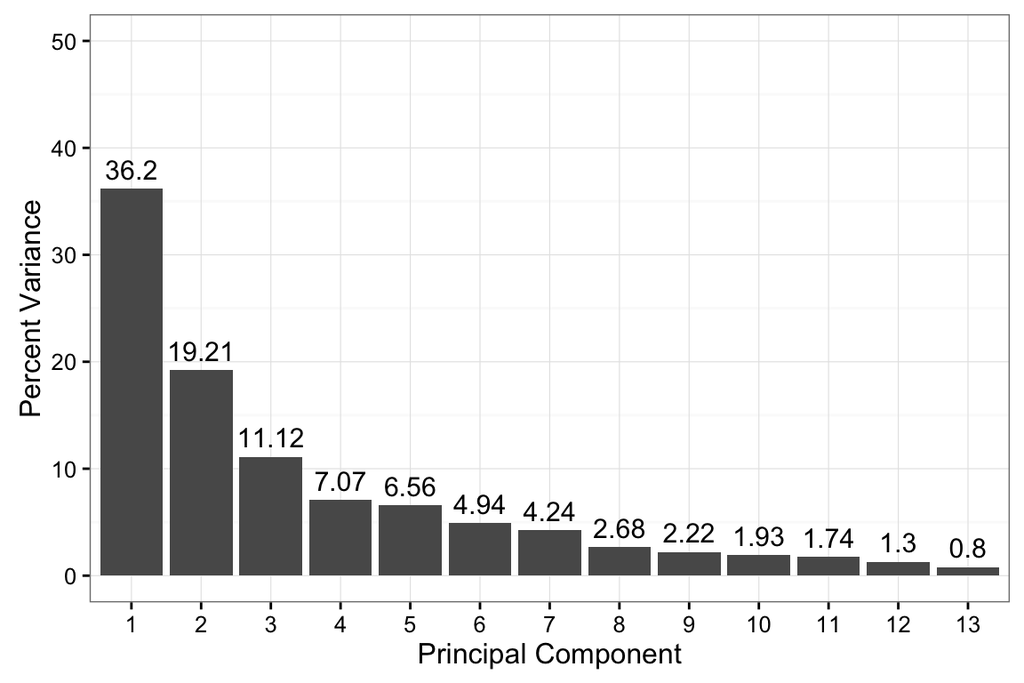

```r
perc_data <- data.frame(percent=percent, PC=1:length(percent))
ggplot(perc_data, aes(x=factor(PC), y=percent)) +
  geom_bar(stat="identity") +
  geom_text(aes(label=round(percent, 2)), size=4, vjust=-.5) +
  ylim(0, 50) +
  xlab("Principal Component") +
  ylab("Percent Variance")
```

*Principal components 1-4 explain 36%, 19%, 11%, and 7% of the variance, respectively.*